# Horror Movie Reviewers Network

Alejandro Hernandez Segura, Zahra Bakari

Monday, June 08, 2015

### 1. First, we load the network from a text file in edgelist form and turn it into a bipartite graph.

```r
# read the data, turn into graph object
horror_movies <- read.csv('horror_movies.txt', sep = ';', header = FALSE)
h <- graph.data.frame(horror_movies, directed = FALSE)

# turn graph into bipartite
V(h)$type <- V(h)$name %in% horror_movies[,1]

# check if bipartite
igraph::is.bipartite(h)
```

```
## [1] TRUE
```

## User-User Network

### 2. We extract the user-user projection and add the following information for each user:

- gender
- the age group
- occupation
- randomly generated name

```r
# user to user projection
users_proj <- bipartite.projection(h)$proj2

# we add user information
users <- read.csv('user_info.txt', sep = ';', header = FALSE)
names(users) <- c('user_id', 'gender', 'age_group', 'occupation')
u <- get.data.frame(users_proj)
user_net <- graph.data.frame(u, directed = FALSE, vertices = users)

# here we use the randomNames package to assign users names
# (it's easier to identify users by a name than a number)
# library(randomNames)
# random_names <- randomNames(length(user_net), gender=V(user_net)$gender)
# save(random_names, file = 'random_names.Rdata')
load('random_names.Rdata')
V(user_net)$user_random_name <- random_names
```

### 3. Now, we examine the user information.

```r
summary(user_net)
```

```
## IGRAPH UNW- 589 34045 --
## attr: name (v/c), gender (v/c), age_group (v/c), occupation (v/c),
##   user_random_name (v/c), weight (e/n)
```

```r
table(V(user_net)$gender)
```

```
##
##   F   M
## 135 454
```

```r
table(V(user_net)$age_group)
```

```
##
##    18-24    25-34    35-44    45-49    50-55      56+ Under 18
##      134      247       96       36       32       18       26
```

```r
table(V(user_net)$occupation)
```

```
##
##      academic/educator                 artist         clerical/admin
##                     44                     26                     24
##   college/grad student       customer service     doctor/health care
##                    104                      9                     16
##   executive/managerial              homemaker           K-12 student
##                     52                     11                     23
##                 lawyer other or not specified             programmer
##                     13                     61                     38
##                retired        sales/marketing              scientist
##                      7                     24                     19
##          self-employed    technician/engineer    tradesman/craftsman
##                     23                     45                      8
##             unemployed                 writer
##                     11                     31
```

### 4. We examine assortativity of gender, age_group, occupation.

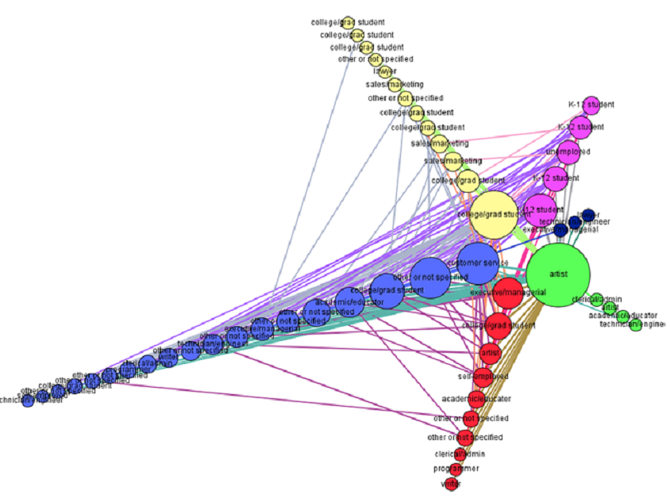

```r
# homophily by gender
# table(V(user_net)$gender)
gender <- as.factor(V(user_net)$gender)
gender <- as.integer(gender)
# table(gender)
assortativity.nominal(user_net, gender, directed = FALSE)
```

```
## [1] 0.004567059
```

```r
# homophily by age
# table(V(user_net)$age_group)
age_group <- as.factor(V(user_net)$age_group)
age_group <- as.integer(age_group)
# table(age_group)
assortativity.nominal(user_net, age_group, directed = FALSE)
```

```
## [1] 0.005232196
```

```r
# homophily by occupation
# table(V(user_net)$occupation)
occupation <- as.factor(V(user_net)$occupation)
job <- as.integer(occupation)
# table(job)
assortativity.nominal(user_net, job, directed = FALSE)
```

```
## [1] -0.001657487
```

### 5. CUG tests

That is to say, are movie reviewers likely to around others who are similar than them in terms of gender, age, or occupation? Null Hypothesis: the likelihood that users are around similar users is due to random edge formation.

```r
# user_gender_CUG <- mycugtest(user_net, assortativity.nominal, types = gender)
# save(user_gender_CUG, file = 'user_gender_CUG.Rdata')
load('user_gender_CUG.Rdata')
print.cug.test(user_gender_CUG)
```

```
##
## Univariate Conditional Uniform Graph Test
##
## Conditioning Method: size
## Graph Type:
## Diagonal Used: FALSE
## Replications: 1000
##
## Observed Value: 0.004567059
## Pr(X>=Obs): 0.008
## Pr(X<=Obs): 0.992
```

```r
# plot.cug.test(user_gender_CUG)

# note: the CUG test will take some time; about 1min30sec on my computer
# user_age_CUG <- mycugtest(user_net, assortativity.nominal, types = age_group)
#save(user_age_CUG, file = 'user_age_CUG.Rdata')
load('user_age_CUG.Rdata')
print.cug.test(user_age_CUG)
```

```
##
## Univariate Conditional Uniform Graph Test
##
## Conditioning Method: size
## Graph Type:
## Diagonal Used: FALSE
## Replications: 1000
##
## Observed Value: 0.005232196
## Pr(X>=Obs): 0
## Pr(X<=Obs): 1
```

```r
# plot.cug.test(user_age_CUG)

# user_job_CUG <- mycugtest(user_net, assortativity.nominal, types = job)
# save(user_job_CUG, file = 'user_job_CUG.Rdata')
load('user_job_CUG.Rdata')
print.cug.test(user_job_CUG)
```

```
##
## Univariate Conditional Uniform Graph Test
##
## Conditioning Method: size
## Graph Type:
## Diagonal Used: FALSE
## Replications: 1000
##
## Observed Value: -0.001657487
## Pr(X>=Obs): 0.494
## Pr(X<=Obs): 0.506
```

```r
# plot.cug.test(user_job_CUG)
```

##### Gender and age group are significant.

### 6. QAP tests

Null hypothesis: The likelihood that users are near similar users to themselves is due to random placement of nodes.

```r
#user_age_qap <- myqaptest(user_net, assortativity.nominal, types = age_group, directed = FALSE)
load('user_age_qap.Rdata')
summary.qaptest(user_age_qap)
```

```
##
## QAP Test Results
##
## Estimated p-values:
##  p(f(perm) >= f(d)): 0.001
##  p(f(perm) <= f(d)): 0.999
##
## Test Diagnostics:
##  Test Value (f(d)): 0.005232196
##  Replications: 1000
##  Distribution Summary:
##      Min:     -0.01075723
##      1stQ:    -0.004365496
##      Med:     -0.002807511
##      Mean:    -0.002805051
##      3rdQ:    -0.001435622
##      Max:     0.005749593
```

```r
# plot.qaptest(user_age_qap)

#user_gender_qap <- myqaptest(user_net, assortativity.nominal, types = gender, directed = FALSE)
load('user_gender_qap.Rdata')
summary.qaptest(user_gender_qap)
```

```
##
## QAP Test Results
##
## Estimated p-values:
##  p(f(perm) >= f(d)): 0.046
##  p(f(perm) <= f(d)): 0.954
##
## Test Diagnostics:
##  Test Value (f(d)): 0.004567059
##  Replications: 1000
##  Distribution Summary:
##      Min:     -0.01276835
##      1stQ:    -0.005616231
##      Med:     -0.003162271
##      Mean:    -0.002884374
##      3rdQ:    -0.0006069091
##      Max:     0.01485909
```

```r
# plot.qaptest(user_gender_qap)

#user_job_qap <- myqaptest(user_net, assortativity.nominal, types = job, directed = FALSE)
load('user_job_qap.Rdata')
summary.qaptest(user_job_qap)
```

```
##
## QAP Test Results
##
## Estimated p-values:
##  p(f(perm) >= f(d)): 0.204
##  p(f(perm) <= f(d)): 0.796
##
## Test Diagnostics:
##  Test Value (f(d)): -0.001657487
##  Replications: 1000
##  Distribution Summary:
##      Min:     -0.005900627
##      1stQ:    -0.003443943
##      Med:     -0.002714663
##      Mean:    -0.002679584
##      3rdQ:    -0.001919428
##      Max:     0.000894107
```

```r
# plot.qaptest(user_job_qap)
```

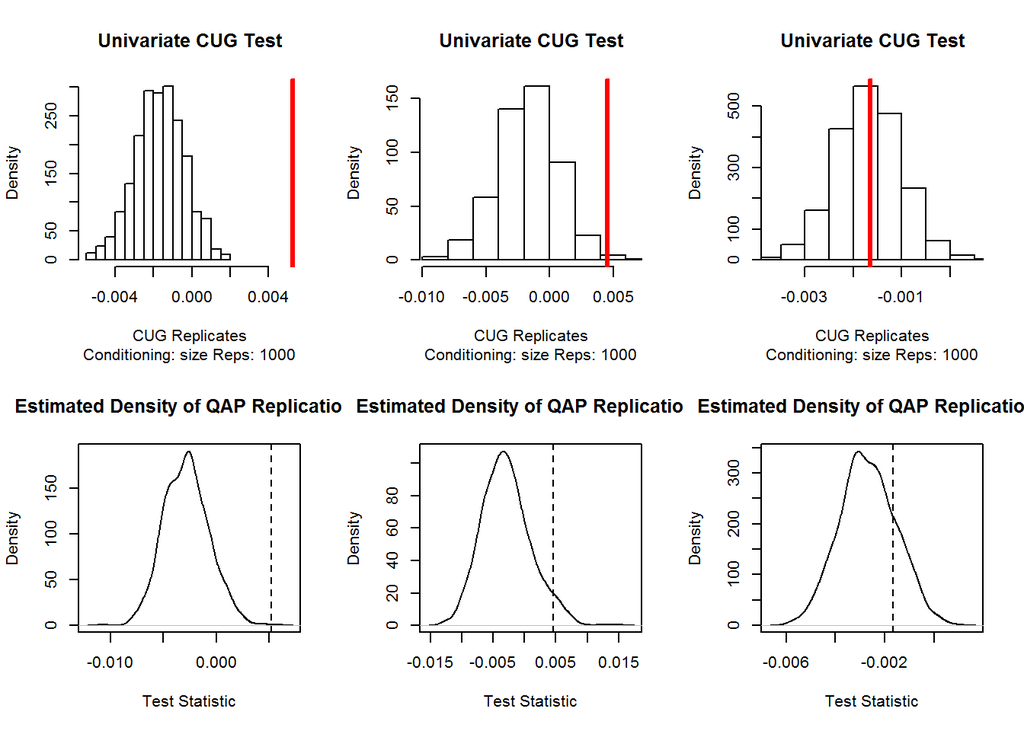

```r
par(mfrow=c(2,3))
plot.cug.test(user_age_CUG)
plot.cug.test(user_gender_CUG)
plot.cug.test(user_job_CUG)
plot.qaptest(user_age_qap)
plot.qaptest(user_gender_qap)
plot.qaptest(user_job_qap)
```

```r
par(mfrow=c(1,1))
```

### 7. Now, we try to quantify the effects of gender and age by constructing an ERGM model.

```r
# ergm models of whole user-user projection ----------------------------------

# we tried to add these network measures to try to improve the model
#V(user_net)$deg.cen <- degree(user_net, normalized = TRUE)
#V(user_net)$cness <- closeness(user_net)
#V(user_net)$bness <- betweenness(user_net)
#V(user_net)$ev.cen <- evcent(user_net)$vector
#V(user_net)$pgrank <- page.rank(user_net)$vector
#V(user_net)$bon.75 <- bonpow(user_net, exponent = .75)
#V(user_net)$bon.neg1 <- bonpow(user_net, exponent = -1)
#V(users.flt)$trans <- transitivity(user_net, 'local')

# our base model:
# user.net <- asNetwork(user_net)
# user_M0 <- ergm(user.net ~ edges, verbose = T)
load('user_M0.Rdata')
summary(user_M0)
```

```
##
## ==========================
## Summary of model fit
## ==========================
##
## Formula:   user.net ~ edges
##
## Iterations:  5 out of 20
##
## Monte Carlo MLE Results:
##        Estimate Std. Error MCMC % p-value
## edges -1.407661   0.006047      0  <1e-04 ***
## ---
## Signif. codes:  0 '***' 0.001 '**' 0.01 '*' 0.05 '.' 0.1 ' ' 1
##
##      Null Deviance: 240059  on 173166  degrees of freedom
##  Residual Deviance: 240059  on 173165  degrees of freedom
##
## AIC: 240061    BIC: 240071    (Smaller is better.)
```

```r
# user_m0.gofm <- gof(user_M0, GOF=~model)
# user_m0.gofm
# plot(user_m0.gofm)

# user_m0.gofm <- gof(user_M0)
# plot(user_m0.gofm)

#user_M1 <- ergm(user.net ~ edges + degree(7), verbose = T)
#user_M1 <- ergm(user.net ~ edges + nodecov('deg.cen') + degree(7), verbose = T)
#user_M1 <- ergm(user.net ~ edges + nodematch('gender', diff=T), verbose = T)
#user_M1 <- ergm(user.net ~ edges + nodematch('age_group', diff=T), verbose = T)
#user_M1 <- ergm(user.net ~ edges + nodematch('gender', diff=T) + nodematch('age_group', diff=T), verbose = T)
#user_M1 <- ergm(user.net ~ edges + degree(c(6, 8)) + nodematch('gender', diff=T) + nodematch('age_group', diff=T), verbose = T)
#save(user_M1, file = 'user_m1.Rdata')
load('user_m1.Rdata')
summary(user_M1)
```

```
##
## ==========================
## Summary of model fit
## ==========================
##
## Formula:   user.net ~ edges + degree(8) + nodematch("gender", diff = T) +
##     nodematch("age_group", diff = T)
##
## Iterations:  20 out of 20
##
## Monte Carlo MLE Results:
##                              Estimate Std. Error MCMC % p-value
## edges                        -1.39831    0.01439      3 < 1e-04 ***
## degree8                       4.28061         NA     NA      NA
## nodematch.gender.F            0.05960    0.04385      3 0.17410
## nodematch.gender.M           -0.01604    0.02217      2 0.46936
## nodematch.age_group.18-24    -0.03862    0.03091      2 0.21151
## nodematch.age_group.25-34     0.02859    0.02164      3 0.18638
## nodematch.age_group.35-44    -0.03004    0.05092      3 0.55525
## nodematch.age_group.45-49     0.19075    0.13939      2 0.17115
## nodematch.age_group.50-55     0.25017    0.11518      4 0.02985 *
## nodematch.age_group.56+      -1.61323    0.50567      2 0.00142 **
## nodematch.age_group.Under 18  0.86920    0.28935      1 0.00266 **
## ---
## Signif. codes:  0 '***' 0.001 '**' 0.01 '*' 0.05 '.' 0.1 ' ' 1
##
##      Null Deviance: 240059  on 173166  degrees of freedom
##  Residual Deviance: 171544  on 173155  degrees of freedom
##
## AIC: 171566    BIC: 171677    (Smaller is better.)
```

### 8. With the full graph we do not get a good model, so here we filter our users network.

```r
edge.weights <- E(user_net)$weight
# hist(edge.weights)
table(edge.weights)
```

```
## edge.weights
##     1     2     3     4     5     6     7     8     9    10    11    12
## 26166  5153  1539   572   273   146    72    50    27    16    11     5
##    13    14    15    16    18
##     6     2     3     3     1
```

```r
# lots of edges <= 2 means that alot of users don't connect, don't review the same movies

# remove edges with weights less than 7 and age group 50-55
# this was done because there were too few users in this age group and
# they would create errors in the model
users.flt <- igraph::delete.edges(user_net , which(edge.weights < 7))
users.flt <- igraph::delete.vertices(users.flt , which(V(users.flt)$age_group == '50-55'))

# create a histogram of weighted degree
weighted_degree <- graph.strength(users.flt)
# hist(weighted_degree)
table(weighted_degree)
```

```
## weighted_degree
##   0   7   8  14  15  21  22  23  26  30  32  35  39  41  42  47  49  51
## 505   9   5   1   1   1   1   3   1   1   1   1   1   2   1   1   1   1
##  60  64  66  67  69  72  73  76  84  97 103 134 142 149 174 242 247 283
##   1   1   1   1   1   1   1   1   2   1   1   1   1   1   1   1   1   1
## 387
##   1
```

```r
# Remove vertices with weighted degrees less than 7
users.flt <- igraph::delete.vertices(users.flt , which(weighted_degree < 7))

# remove singleton nodes
remove.singletons <- function(graph){
  deg <- degree(graph)
  singles <- which(deg == 0)
  new_graph <- graph - singles
  return(new_graph)
}
users.flt <- remove.singletons(users.flt)
# weighted_degree <- graph.strength(users.flt)
# table(weighted_degree)
# plot(users.flt, vertex.label = V(users.flt)$user_random_name)
table(degree(users.flt))
```

```
##
##  1  2  3  4  5  6  7  8  9 10 11 12 13 15 16 18 24 25 30 40
## 14  2  6  3  4  3  2  2  4  1  1  1  1  1  1  2  1  1  1  1
```

```r
# degree centrality and eigenvector were the best ones
#V(users.flt)$deg.cen <- degree(users.flt, normalized = TRUE)
#V(users.flt)$cness <- closeness(users.flt)
#V(users.flt)$bness <- betweenness(users.flt)
V(users.flt)$ev.cen <- evcent(users.flt)$vector
#V(users.flt)$pgrank <- page.rank(users.flt)$vector
#V(users.flt)$bon.75 <- bonpow(users.flt, exponent = .75)
#V(users.flt)$bon.neg1 <- bonpow(users.flt, exponent = -1)
#V(users.flt)$trans <- transitivity(users.flt, 'global')
#E(users.flt)$weight
```

### 9. The base ergm model of the filtered user network with only edges

```r
# our base model
# user_flt.net <- asNetwork(users.flt)
# user_flt_M0 <- ergm(user_flt.net ~ edges, verbose = T)
load('user_flt_M0.Rdata')
summary(user_flt_M0)
```

```
##
## ==========================
## Summary of model fit
## ==========================
##
## Formula:   user_flt.net ~ edges
##
## Iterations:  5 out of 20
##
## Monte Carlo MLE Results:
##       Estimate Std. Error MCMC % p-value
## edges -1.77601    0.07804      0  <1e-04 ***
## ---
## Signif. codes:  0 '***' 0.001 '**' 0.01 '*' 0.05 '.' 0.1 ' ' 1
##
##      Null Deviance: 1838  on 1326  degrees of freedom
##  Residual Deviance: 1838  on 1325  degrees of freedom
##
## AIC: 1840    BIC: 1845    (Smaller is better.)
```

```r
#user_m0.gofm <- gof(user_flt_M0, GOF=~model)
#user_m0.gofm
#plot(user_m0.gofm)

#user_m0.gofm <- gof(user_flt_M0)
#user_m0.gofm
#par(mfrow=c(3,1))
#plot(user_m0.gofm)
#par(mfrow=c(1,1))
```

### 10. The improved model (and other models we tried, but weren’t as good):

```r
# add degree(7) nodes, which were underrepresented in first model
# user_flt_M1 <- ergm(user_flt.net ~ edges + degree(7), verbose = T)
# and other ergm models we tried
# user_flt_M1 <- ergm(user_flt.net ~ edges + degree(7) +
#                    nodematch('gender', diff=T), verbose = T)
#user_flt_M1 <- ergm(user_flt.net ~ edges + degree(7) +
#                    nodematch('age_group', diff=T), verbose = T)
#user_flt_M1 <- ergm(user_flt.net ~ edges + degree(7) +
#                    nodematch('gender') +
#                    nodematch('age_group', diff=T), verbose = T)
#user_flt_M1 <- ergm(user_flt.net ~ edges + degree(7) + nodematch('gender') +
#                    nodematch('age_group', diff=T),
#                    control = control.ergm(MCMC.burnin = 50000,
#                                           MCMC.interval = 5000), verbose = T)
#user_flt_M1 <- ergm(user_flt.net ~ edges + nodecov('deg.cen') +
#                    degree(7), verbose = T) # so far, this is the best model
#user_flt_M2 <- ergm(user_flt.net ~ edges + nodecov('cness') +
#                    degree(7), verbose = T)
#user_flt_M2 <- ergm(user_flt.net ~ edges + nodecov('bness') +
#                    degree(7), verbose = T)
#user_flt_M2 <- ergm(user_flt.net ~ edges + nodecov('ev.cen') +
#                    degree(7), verbose = T)
#user_flt_M1 <- ergm(user_flt.net ~ edges + nodecov('pgrank') +
#                    degree(7), verbose = T)
#summary(user_flt_M1)
#summary(user_flt_M2)

#user_flt_M3 <- ergm(user_flt.net ~ edges
#                    + nodecov('ev.cen')
#                    + nodematch('gender', diff = TRUE)
#                    + degree(7), verbose = T)
#user_flt_M3 <- ergm(user_flt.net ~ edges
#                    + nodecov('ev.cen')
#                    + nodematch('age_group', diff = TRUE)
#                    + degree(7), verbose = T)
#user_flt_M3 <- ergm(user_flt.net ~ edges
#                    + nodecov('ev.cen')
#                    + nodematch('gender', diff = TRUE)
#                    + nodematch('age_group', diff = TRUE)
#                    + degree(7), verbose = T)
load('user_flt_M3.Rdata')
summary(user_flt_M3)
```

```
##
## ==========================
## Summary of model fit
## ==========================
##
## Formula:   user_flt.net ~ edges + nodecov("ev.cen") + nodematch("gender",
##     diff = TRUE) + nodematch("age_group", diff = TRUE) + degree(c(1,
##     7))
##
## Iterations:  2 out of 20
##
## Monte Carlo MLE Results:
##                              Estimate Std. Error MCMC % p-value
## edges                         -6.6111     0.4829      0  <1e-04 ***
## nodecov.ev.cen                 6.8239     0.5072      0  <1e-04 ***
## nodematch.gender.F             2.6378     0.5470      0  <1e-04 ***
## nodematch.gender.M             0.1104     0.2490      0   0.658
## nodematch.age_group.18-24      0.5958     0.5421      0   0.272
## nodematch.age_group.25-34     -0.3127     0.2902      0   0.281
## nodematch.age_group.35-44      0.1243     0.6293      0   0.843
## nodematch.age_group.45-49      1.1148     1.1302      0   0.324
## nodematch.age_group.Under 18  -1.0411     1.1467      0   0.364
## degree1                        2.7710     0.5424      0  <1e-04 ***
## degree7                       -0.4815     0.7527      0   0.522
## ---
## Signif. codes:  0 '***' 0.001 '**' 0.01 '*' 0.05 '.' 0.1 ' ' 1
##
##      Null Deviance: 1838.2  on 1326  degrees of freedom
##  Residual Deviance:  526.1  on 1315  degrees of freedom
##
## AIC: 548.1    BIC: 605.2    (Smaller is better.)
```

```r
mcmc.diagnostics(user_flt_M3)
```

```
## Sample statistics summary:
##
## Iterations = 16384:4209664
## Thinning interval = 1024
## Number of chains = 1
## Sample size per chain = 4096
##
## 1. Empirical mean and standard deviation for each variable,
##    plus standard error of the mean:
##
##                                  Mean      SD Naive SE Time-series SE
## edges                         0.86353 10.8096  0.16890        0.30869
## nodecov.ev.cen                0.32479  9.2355  0.14430        0.27913
## nodematch.gender.F            0.38989  2.3794  0.03718        0.05990
## nodematch.gender.M            0.24609  9.0477  0.14137        0.25442
## nodematch.age_group.18-24     0.06421  1.9842  0.03100        0.05308
## nodematch.age_group.25-34     0.39551  3.9350  0.06149        0.11361
## nodematch.age_group.35-44     0.14038  1.6840  0.02631        0.03410
## nodematch.age_group.45-49    -0.32007  0.9630  0.01505        0.03024
## nodematch.age_group.Under 18 -0.05200  0.8672  0.01355        0.01769
## degree1                       0.12231  2.5354  0.03962        0.06703
## degree7                       0.04980  1.3492  0.02108        0.02190
##
## 2. Quantiles for each variable:
##
##                                2.5%    25%     50%   75% 97.5%
## edges                        -20.00 -6.000 1.00000 8.000 22.00
## nodecov.ev.cen               -17.55 -5.905 0.08173 6.605 18.43
## nodematch.gender.F            -4.00 -1.000 0.00000 2.000  5.00
## nodematch.gender.M           -17.00 -6.000 0.00000 6.000 18.62
## nodematch.age_group.18-24     -4.00 -1.000 0.00000 1.000  4.00
## nodematch.age_group.25-34     -7.00 -2.000 0.00000 3.000  8.00
## nodematch.age_group.35-44     -3.00 -1.000 0.00000 1.000  4.00
## nodematch.age_group.45-49     -2.00 -1.000 0.00000 0.000  1.00
## nodematch.age_group.Under 18  -1.00 -1.000 0.00000 0.000  2.00
## degree1                       -5.00 -2.000 0.00000 2.000  5.00
## degree7                       -2.00 -1.000 0.00000 1.000  3.00
##
##
## Sample statistics cross-correlations:
```

[output cut: 134 more lines]

```
##
## Individual P-values (lower = worse):
##                        edges               nodecov.ev.cen
##                  0.740720321                  0.812780071
##           nodematch.gender.F           nodematch.gender.M
##                  0.852537434                  0.948064641
##    nodematch.age_group.18-24    nodematch.age_group.25-34
##                  0.338492844                  0.050992590
##    nodematch.age_group.35-44    nodematch.age_group.45-49
##                  0.002668348                  0.302844894
## nodematch.age_group.Under 18                      degree1
##                  0.618569433                  0.807485708
##                      degree7
##                  0.943324658
## Joint P-value (lower = worse):  0.1371138 .
```

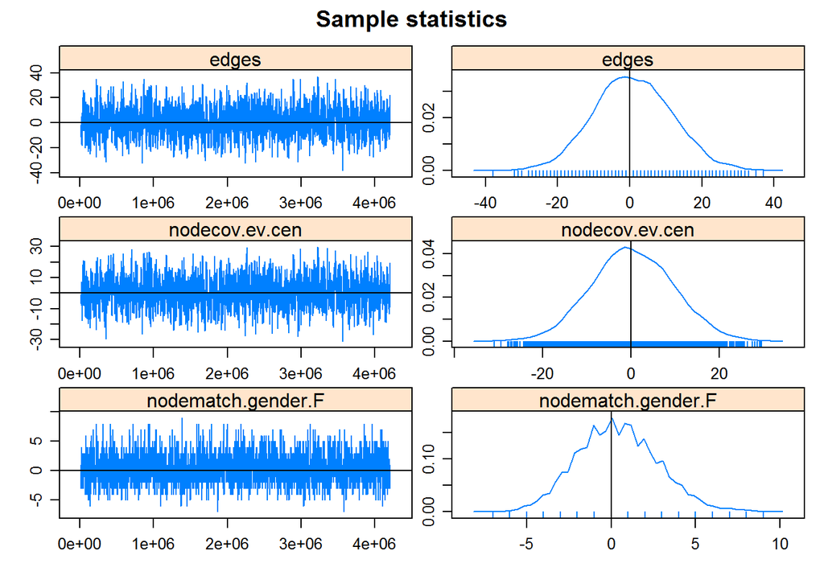

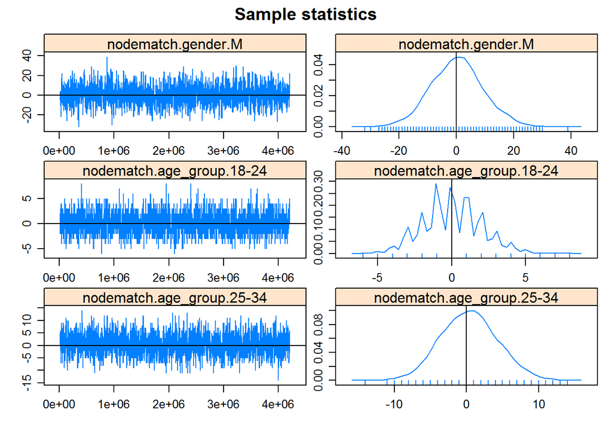

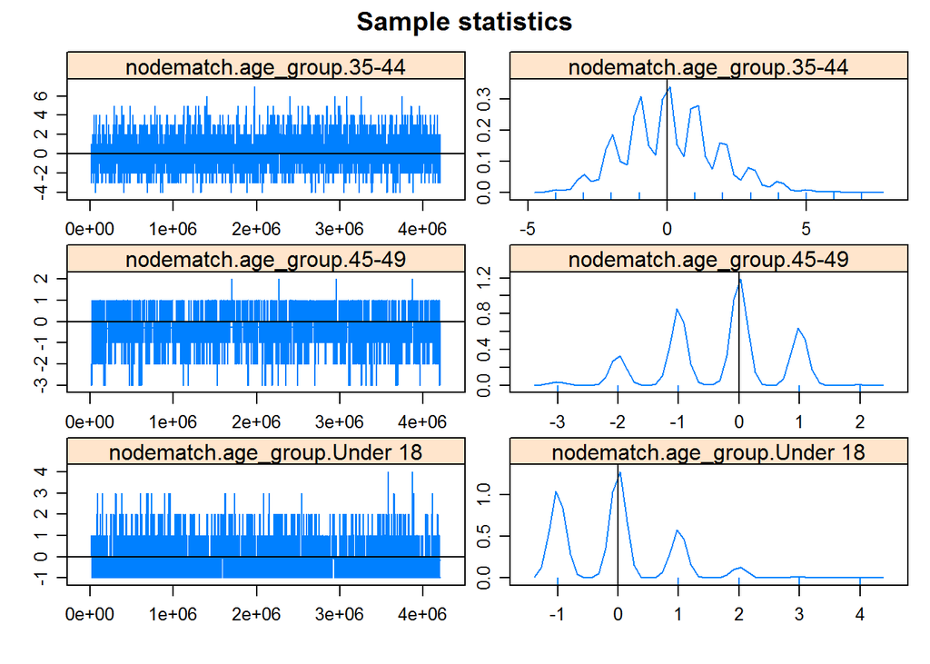

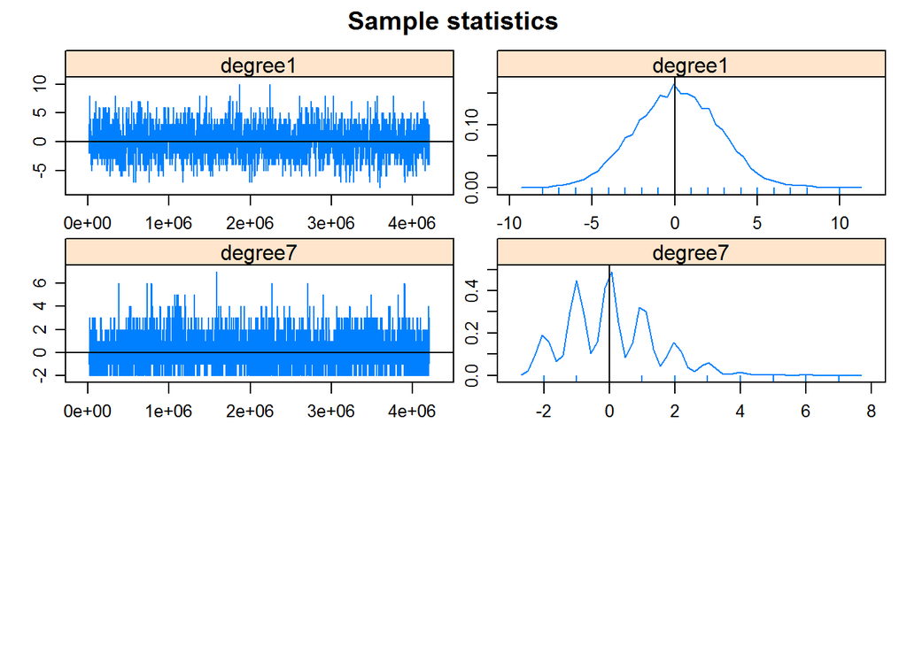

```
##
## Recent changes in the ergm estimation algorithm mean that these plots can no longer be used to ensure that the mean statistics from the model match the observed network statistics. For that functionality, please use the GOF command: gof(ergmFitObject, GOF=~model).
```

```r
user_m3.gofm <- gof(user_flt_M3, GOF=~model)
user_m3.gofm
```

```
##
## Goodness-of-fit for model statistics
##
##                                   obs      min    mean     max MC p-value
## edges                        192.0000 175.0000 192.800 217.000       1.00
## nodecov.ev.cen               201.4907 184.4825 202.073 223.444       0.98
## nodematch.gender.F             7.0000   3.0000   7.190  12.000       1.00
## nodematch.gender.M           148.0000 129.0000 148.060 171.000       1.00
## nodematch.age_group.18-24      7.0000   1.0000   7.310  12.000       1.00
## nodematch.age_group.25-34     32.0000  22.0000  32.150  41.000       1.00
## nodematch.age_group.35-44      4.0000   0.0000   3.910   8.000       1.00
## nodematch.age_group.45-49      3.0000   0.0000   2.970   5.000       1.00
## nodematch.age_group.Under 18   1.0000   0.0000   1.030   3.000       1.00
## degree1                       14.0000   9.0000  13.930  19.000       1.00
## degree7                        2.0000   0.0000   2.110   7.000       1.00
```

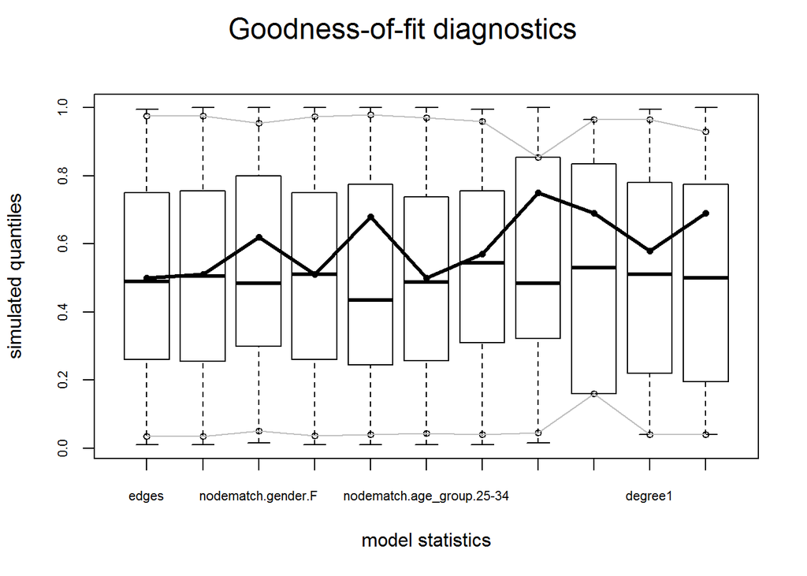

```r
plot(user_m3.gofm)
```

```r
user_m3.gofm <- gof(user_flt_M3)
user_m3.gofm
```

```
##
## Goodness-of-fit for degree
##
##    obs min  mean max MC p-value
## 0    0   0  0.21   2       1.00
## 1   14   6 14.44  21       0.98
## 2    2   0  2.37   6       1.00
## 3    6   1  3.96   9       0.38
## 4    3   1  4.74  11       0.66
## 5    4   0  4.15   9       1.00
## 6    3   0  3.42   9       1.00
## 7    2   0  2.15   5       1.00
## 8    2   0  2.71   6       0.86
## 9    4   0  2.01   6       0.20
## 10   1   0  1.63   7       0.92
## 11   1   0  0.99   5       1.00
## 12   1   0  0.98   4       1.00
## 13   1   0  0.67   3       1.00
## 14   0   0  0.64   3       1.00
## 15   1   0  0.63   3       0.98
## 16   1   0  0.49   3       0.78
## 17   0   0  0.40   3       1.00
## 18   2   0  0.42   3       0.12
## 19   0   0  0.35   2       1.00
## 20   0   0  0.26   2       1.00
## 21   0   0  0.20   2       1.00
## 22   0   0  0.15   1       1.00
## 23   0   0  0.15   1       1.00
## 24   1   0  0.21   1       0.42
## 25   1   0  0.19   2       0.36
## 26   0   0  0.33   2       1.00
## 27   0   0  0.37   2       1.00
## 28   0   0  0.33   2       1.00
## 29   0   0  0.44   3       1.00
## 30   1   0  0.30   2       0.52
## 31   0   0  0.23   3       1.00
## 32   0   0  0.21   1       1.00
## 33   0   0  0.16   2       1.00
## 34   0   0  0.12   1       1.00
## 35   0   0  0.19   2       1.00
```

[output cut: 40 more lines]

```
## esp26   0   0  0.24   2       1.00
## esp27   0   0  0.15   2       1.00
## esp28   0   0  0.10   3       1.00
## esp29   0   0  0.05   1       1.00
## esp30   0   0  0.03   1       1.00
## esp32   0   0  0.01   1       1.00
##
## Goodness-of-fit for minimum geodesic distance
##
##     obs min   mean  max MC p-value
## 1   192 166 188.67  219       0.56
## 2   929 768 880.06 1018       0.30
## 3   201  98 239.48  340       0.40
## 4     4   0   6.09   28       0.96
## Inf   0   0  11.70  101       1.00
```

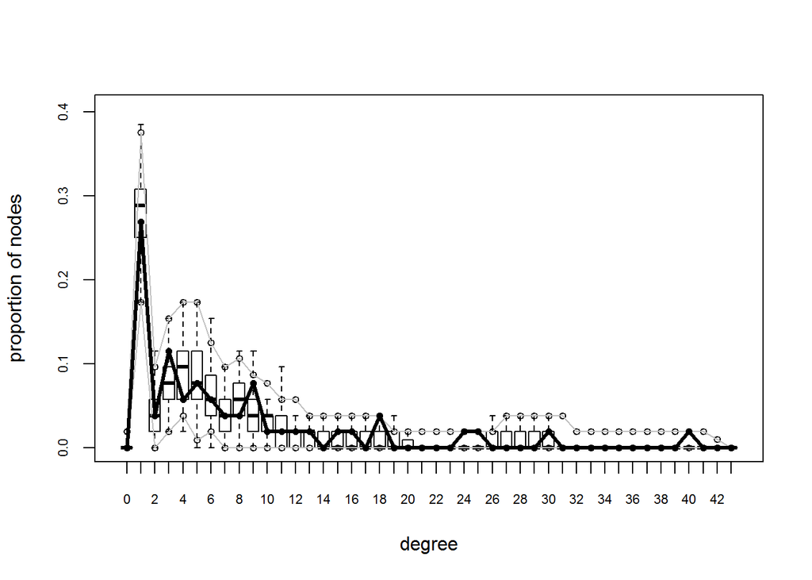

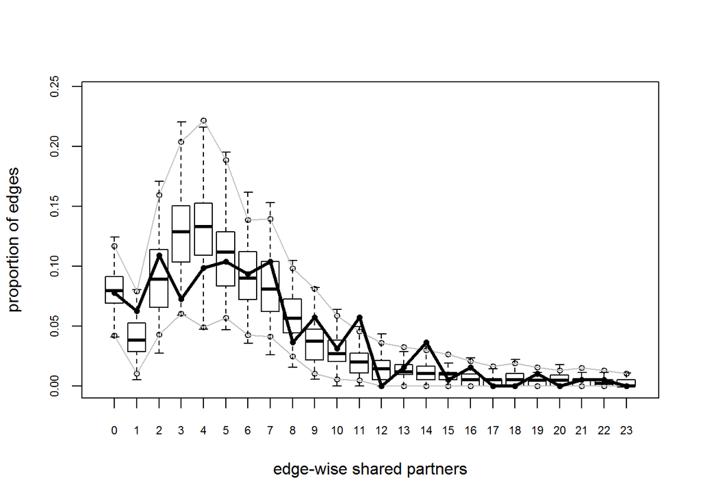

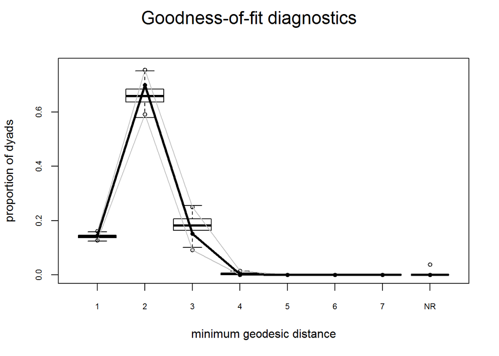

```r
#par(mfrow=c(3,1))
plot(user_m3.gofm)
```

```r
#par(mfrow=c(1,1))
```

### 11. Here we try to interpret the log odds.

```r
# we tried interpreting the log odds, but were unsuccessful, even with constantly referring to the documentation

edge <- coef(user_flt_M3)[1]
ev <- coef(user_flt_M3)[2]
f <- coef(user_flt_M3)[3]
m <- coef(user_flt_M3)[4]
u18 <- coef(user_flt_M3)[5]
u25 <- coef(user_flt_M3)[6]
u35 <- coef(user_flt_M3)[7]
u45 <- coef(user_flt_M3)[8]
under18 <- coef(user_flt_M3)[9]
deg1 <- coef(user_flt_M3)[10]
deg7 <- coef(user_flt_M3)[11]

case1.lo <- edge + ev + f + under18 + deg1
case2.lo <- edge + ev + f + u18 + deg1
case3.lo <- edge + ev + f + u25 + deg1
case4.lo <- edge + ev + f + u35 + deg1
case5.lo <- edge + ev + f + u45 + deg1

case6.lo <- edge + ev + m + under18 + deg1
case7.lo <- edge + ev + m + u18 + deg1
case8.lo <- edge + ev + m + u25 + deg1
case9.lo <- edge + ev + m + u35 + deg1
case10.lo <- edge + ev + m + u45 + deg1

df_females <- data.frame(case1 = invlogit(case1.lo),
                 case2 = invlogit(case2.lo),
                 case3 = invlogit(case3.lo),
                 case4 = invlogit(case4.lo),
                 case5 = invlogit(case5.lo))

df_males <- data.frame(case6 = invlogit(case6.lo),
                 case7 = invlogit(case7.lo),
                 case8 = invlogit(case8.lo),
                 case9 = invlogit(case9.lo),
                 case10 = invlogit(case10.lo))
```

### 12. Community Detection

```r
# community detection --------------------------------------------------------
# run the leading eigenvector clustering using weights
users.eigen <- leading.eigenvector.community(users.flt)
sizes(users.eigen)
```

```
## Community sizes
##  1  2  3  4  5
##  8 11 13 13  7
```

```r
V(users.flt)$eigen.com <- as.character(membership(users.eigen))
#plot(users.flt, vertex.label = V(users.flt)$user_random_name, vertex.color=membership(users.eigen))

# save this graph object as graphml so we can use it in Gephi
# write.graph(users.flt, 'users_flt.graphml', format = 'graphml')

# other community detection algorithms we tried -----------------------------
# run the walktrap community detection
users.walk <- walktrap.community(users.flt)
#users.walk
sizes(users.walk)
```

```
## Community sizes
##  1  2  3  4  5  6  7  8  9 10 11 12 13 14 15 16 17 18 19 20 21 22 23
##  4  8 13  2  3  2  2  3  1  1  1  1  1  1  1  1  1  1  1  1  1  1  1
```

```r
#membership(users.walk)

#users.walk.clust <- as.hclust(users.walk)
#plot(users.walk.clust)
#plot(users.flt, vertex.label=V(users.flt)$user_random_name, vertex.color=membership(users.walk))
```

### other analysis we attempted, but did not use in our report:

```r
# link prediction ------------------------------------------------------------

# compute link prediction by jaccard similarity
link_pred <- similarity.jaccard(users.flt, vids = V(users.flt), mode = c("all"), loops = FALSE)
for (i in 1:ncol(link_pred)){
  link_pred[i, i] <- 0
}

link_pred <- similarity.dice(users.flt, vids = V(users.flt), mode = c("all"))
for (i in 1:ncol(link_pred)){
  link_pred[i, i] <- 0
}

link_pred <- similarity.invlogweighted(users.flt, vids = V(users.flt), mode = c("all"))
for (i in 1:ncol(link_pred)){
  link_pred[i, i] <- 0
}

l <- apply(link_pred, 2, max)

for (k in seq_along(l)) {
  if (l[k] == 1.0) { # l[k] == 1.0 jaccard, l[k] > 5, invlogweighted
  print(paste('k:', k, 'most similar:', which(link_pred[ ,k] == l[k])))
  }
}

# movie-movie projection -----------------------------------------------------
movie_net <- bipartite.projection(h)$proj1
summary(movie_net)
```

```
## IGRAPH UNW- 223 7046 --
## attr: name (v/c), weight (e/n)
```

```r
# Create a histogram of edge weight
edge.weights <- E(movie_net)$weight
table(edge.weights)
```

```
## edge.weights
##    1    2    3    4    5    6    7    8    9   10   11   12   13   14   15
## 4388 1243  518  321  152  111   80   64   39   28   30   17   12   10    4
##   16   17   18   19   20   21   22   23   25   26   27   28
##    7    3    4    1    2    3    2    1    1    1    3    1
```

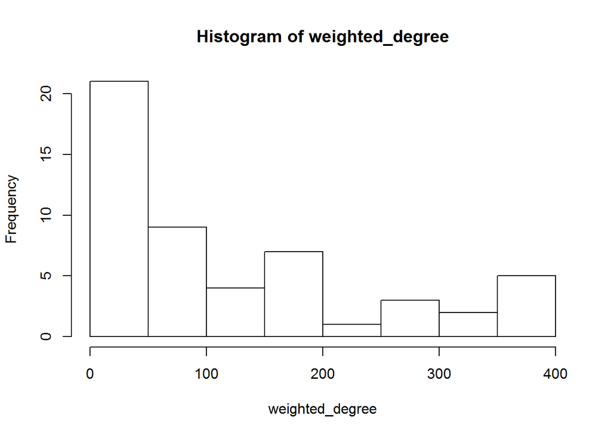

```r
# Remove edges with weights less than 7
movies.flt <- igraph::delete.edges(movie_net , which(edge.weights < 7))
movies.flt <- remove.singletons(movies.flt)

# Create a histogram of weighted degree
weighted_degree <- graph.strength(movies.flt)
hist(weighted_degree)
```

```r
table(weighted_degree)
```

```
## weighted_degree
##   7   8   9  14  15  16  17  31  39  40  46  49  52  53  60  68  79  82
##   7   1   1   1   1   1   2   1   2   2   1   1   1   1   2   1   1   1
##  89  93 108 129 142 146 162 164 165 172 174 176 200 221 268 269 299 303
##   1   1   1   1   1   1   1   1   1   1   1   1   1   1   1   1   1   1
## 306 351 358 384 394 398
##   1   1   1   1   1   1
```

```r
# Remove singleton nodes
remove.singletons <- function(graph){
  deg <- degree(graph)
  singles <- which(deg == 0)
  new_graph <- graph - singles
  return(new_graph)
}

movies.flt <- remove.singletons(movies.flt)

# run walktrap community detection
movies.walk <- walktrap.community(movies.flt)
sizes(movies.walk)
```

```
## Community sizes
##  1  2  3  4  5  6  7  8  9 10 11 12 13 14 15 16 17 18 19 20 21 22
## 14  6  3 11  1  1  1  1  1  1  1  1  1  1  1  1  1  1  1  1  1  1
```

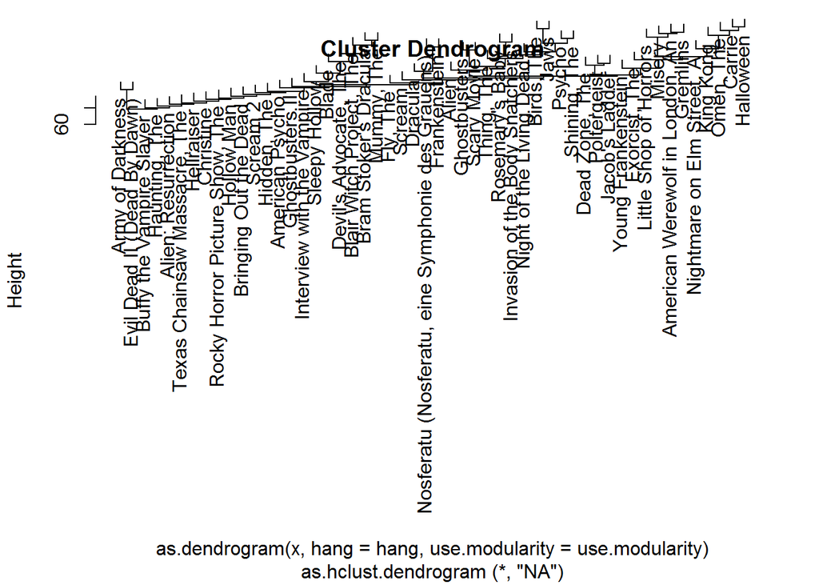

```r
# dendrogram
movies.walk.clust <- as.hclust(movies.walk)
#png('movies_clust.png')
plot(movies.walk.clust)
```

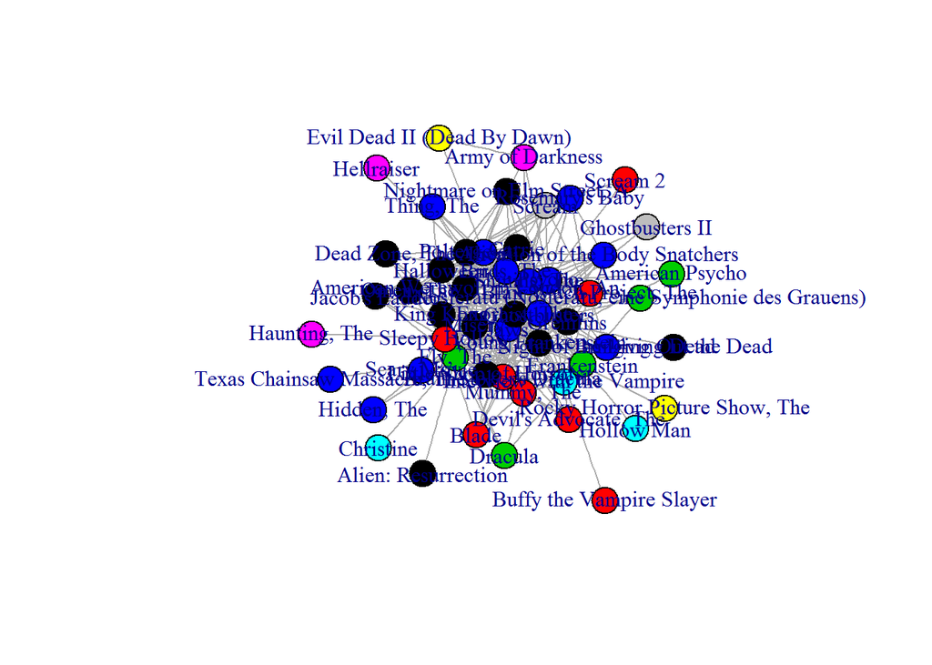

```r
#dev.off()

# filtered movies plot with membership from walktrap
plot(movies.flt, vertex.color=membership(movies.walk))
```

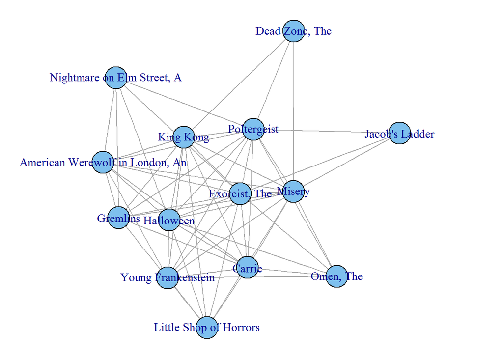

```r
# Extract any one of these clusters into a seperate network
movies.c1 <- induced.subgraph(movies.flt, which(membership(movies.walk)==1))
par(mai=c(.1,.1,.1,.1))
plot(movies.c1)
```